# DATA661 - Time Series Forecasting

Blandon Casenave

10/5/2017

```r
library(ggplot2)
library(forecast)
library(tseries)
library(prophet)
library(stR)
library(zoo)
library(dplyr)
library(Metrics)
```

**Part I - summary statistics and a time series chart**

```
##        ds                   y
##  Min.   :2011-01-01   Min.   :  59.43
##  1st Qu.:2012-04-01   1st Qu.: 444.06
##  Median :2013-07-01   Median : 499.84
##  Mean   :2013-07-01   Mean   : 547.65
##  3rd Qu.:2014-09-30   3rd Qu.: 603.16
##  Max.   :2015-12-31   Max.   :1141.09
##                       NA's   :33
```

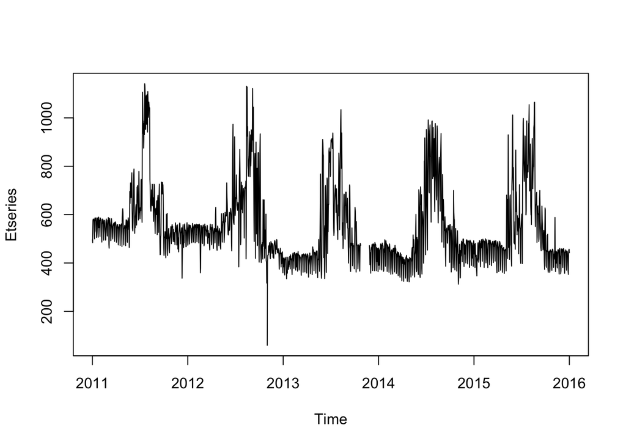

**Part II - Forecast & Prophet decomposition charts for the raw data, seasonality and trend**

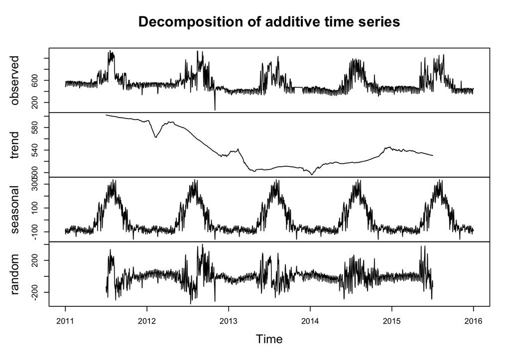

```
## Initial log joint probability = -22.4069
## Optimization terminated normally:
##   Convergence detected: relative gradient magnitude is below tolerance
```

[output not shown]

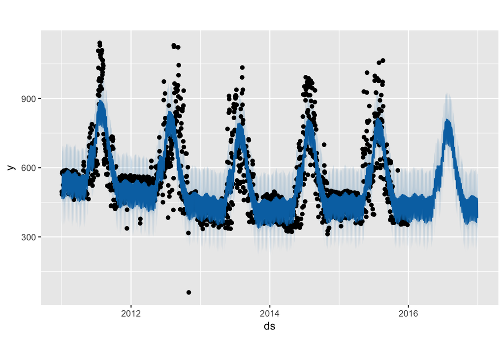

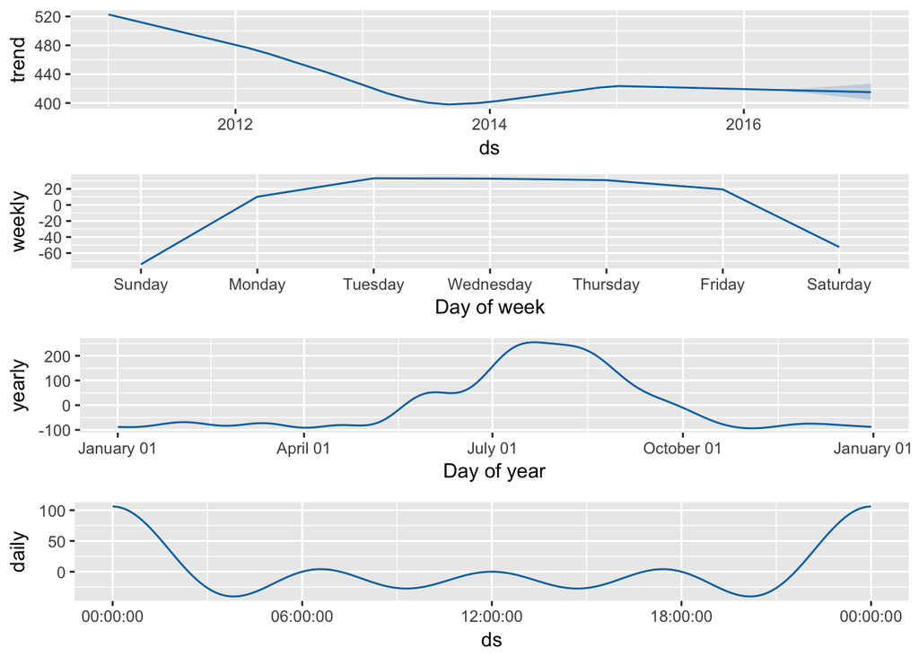

**Part III - forecast data for 2016 ONLY in a data frame for subsequent analysis**

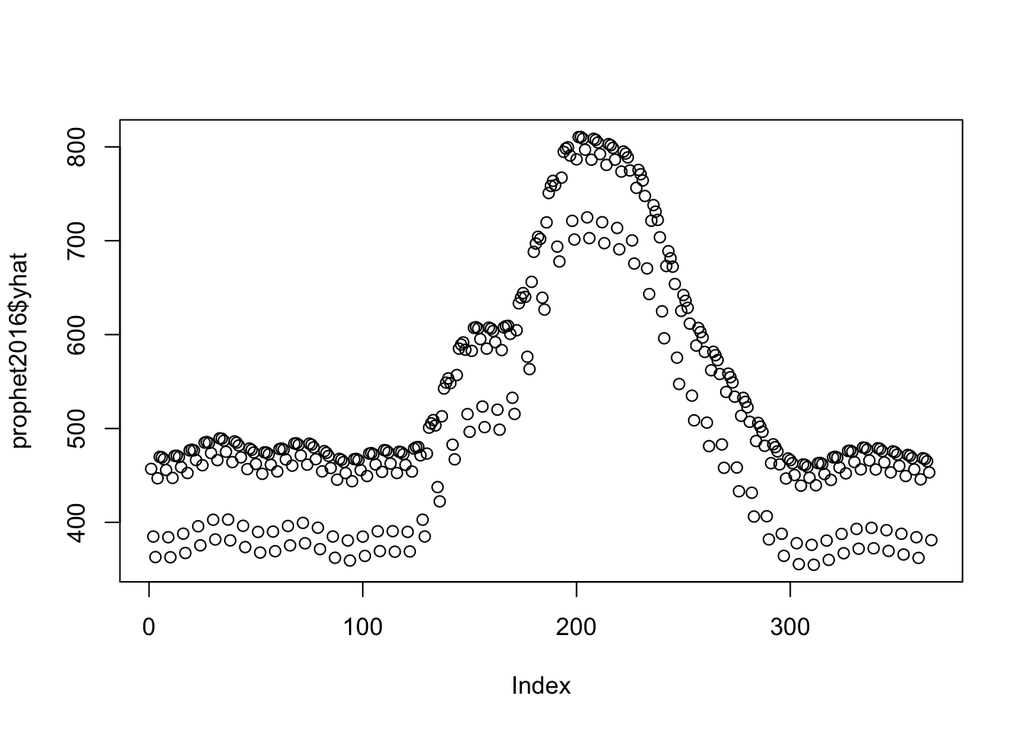

**Part IV - stR Decomposition**

The Str & Propphet compoments depict a similar story when comparing the trends, seasonal and random error plots - that the data appears to be seaonal and somewhat stationary.

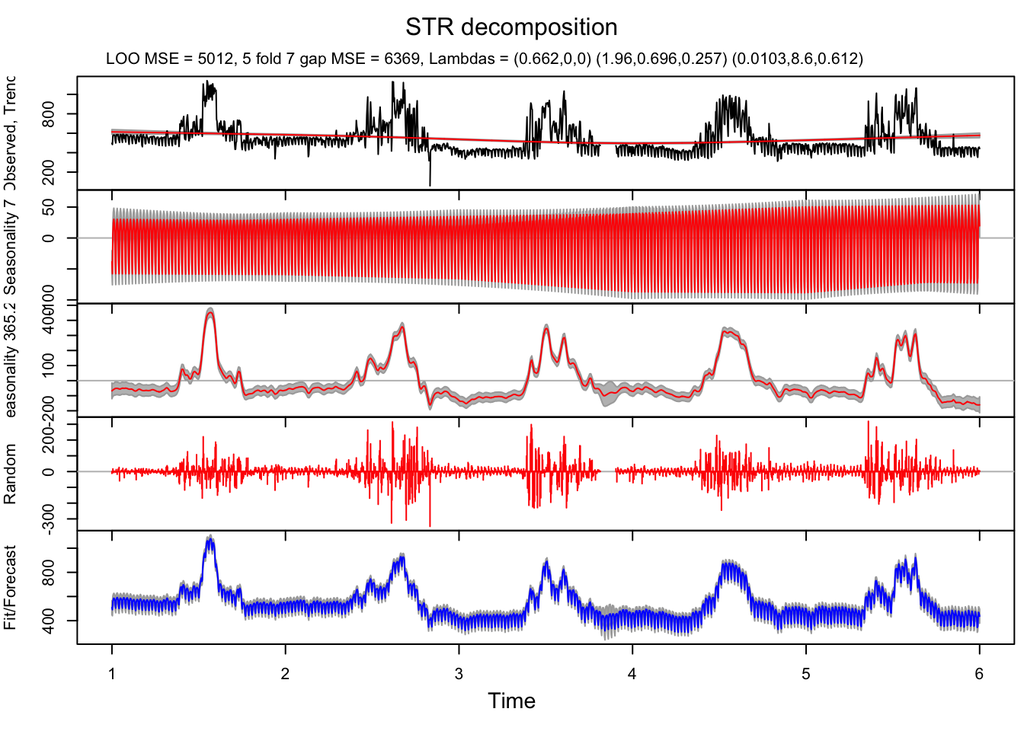

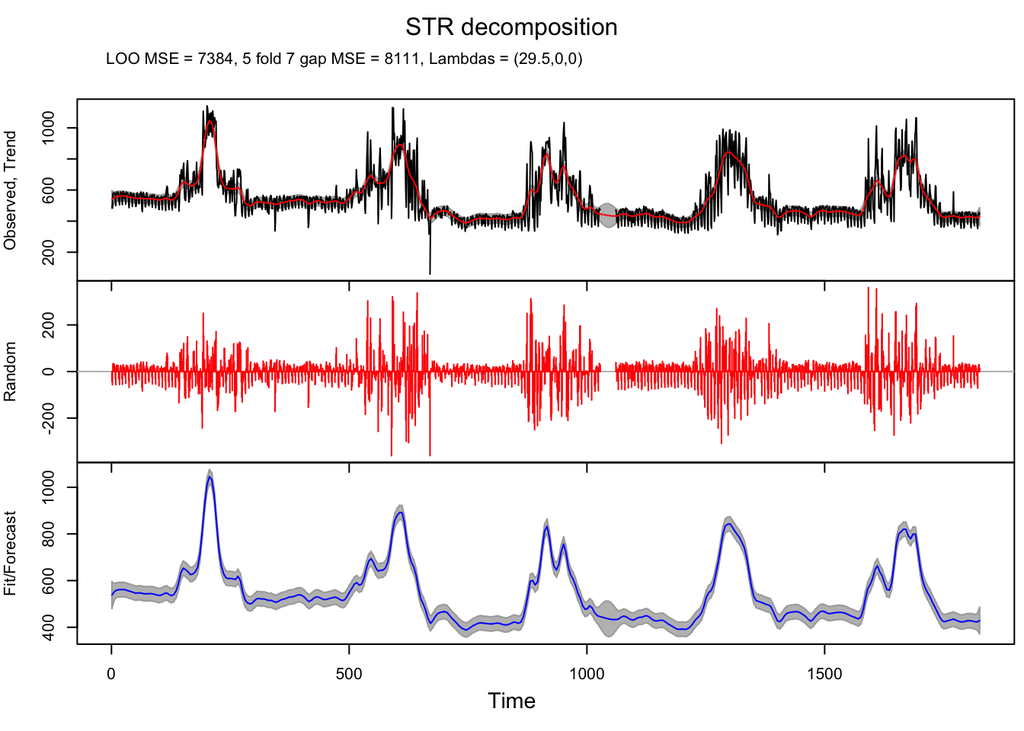

**Part V - Forecast package**

Forecast against test data set. na.approx was used to impute missing data points.

```
##
##  Augmented Dickey-Fuller Test
##
## data:  na.approx(Etseries)
## Dickey-Fuller = -3.4148, Lag order = 12, p-value = 0.05087
## alternative hypothesis: stationary
```

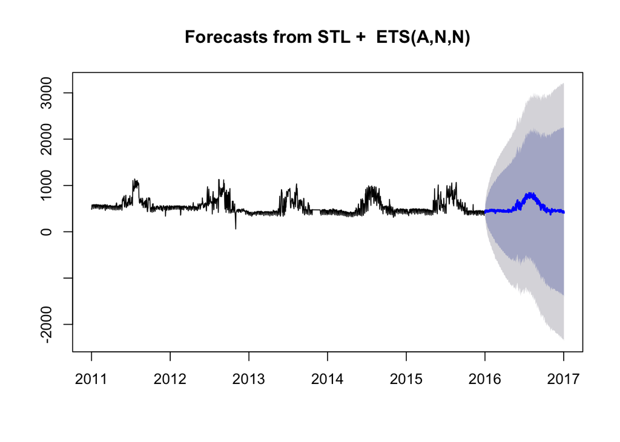

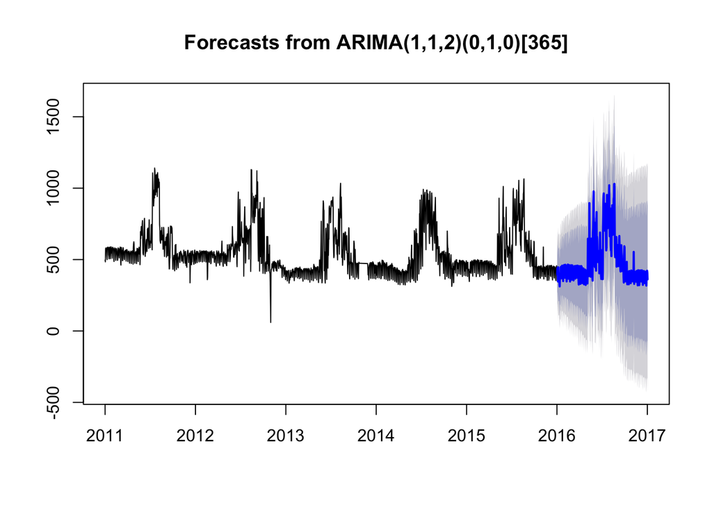

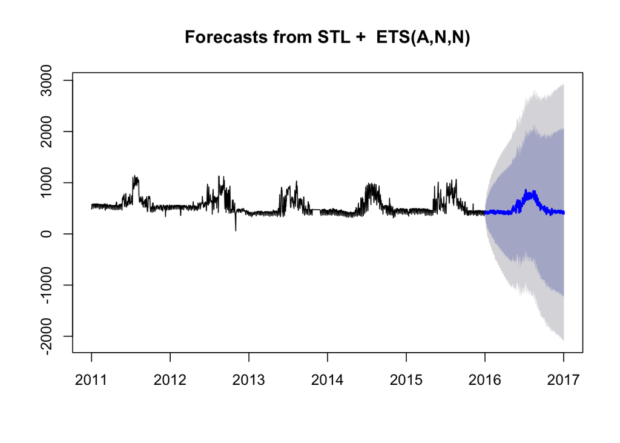

**Part VI Actuals vs. Forecast for 2016**

Based on the RMSE, MAE & MSE being the lowest for the prophet forecast when compared to other methods (ARIMA, Seasonal) from the forecast package - I would say this model was the best peforming of the ones we tested.

```
## [1] 98.99531
```

```
## [1] 108.8976
```

```
## [1] 128.3336
```

```
## [1] 72.15559
```

```
## [1] 77.774
```

```
## [1] 83.82817
```

```
## [1] 9800.071
```

```
## [1] 11858.7
```

```
## [1] 16469.51
```

```
##          rmsematrix
## Prophet    98.99531
## Seasonal  108.89764
## ARIMA     128.33358
```

```
##          maematrix
## Prophet   72.15559
## Seasonal  77.77400
## ARIMA     83.82817
```

```
##          msematrix
## Prophet   9800.071
## Seasonal 11858.696
## ARIMA    16469.508
```

**Part VII - Additional Correlation Test**

Is a basic Pearson’s R correlation test valid, when both variables are seasonal…does this make the comparison linear?

```
## [1] 0.8431467
```

```
## [1] 0.8073314
```

```
## [1] 0.6920107
```

```
##          cormatrix
## Prophet  0.8431467
## Seasonal 0.8073314
## ARIMA    0.6920107
```

Sources: [Time Series](http://www.statmethods.net/advstats/timeseries.html)

fill in missing data [Seasonal Decomposition](https://stackoverflow.com/questions/24694558/seasonal-decompose-of-monthly-data-including-na-in-r)

[Transform to MSTS before you can use AutoSTR](https://cran.r-project.org/web/packages/stR/vignettes/stRvignette.html)

[Prophet Package](https://medium.com/towards-data-science/using-open-source-prophet-package-to-make-future-predictions-in-r-ece585b73687)

[ARIMA Decomposition](https://www.datascience.com/blog/introduction-to-forecasting-with-arima-in-r-learn-data-science-tutorials)